# ACTIVITY: Joins Pivots dataRetrieval

## Load the tidyverse, dataRetrieval, and patchwork packages.

```r
rm(list=ls())
library(tidyverse)
library(dataRetrieval)
library(patchwork)
```

## Problem 1

Using readNWISqw(), read all the chloride (00940) data for the New River at Radford (03171000). Use the head() function to print the beginning of the output from readNWISqw.

```r
Rad <- "03171000"

chl <- "00940"

Rad_Chloride <- readNWISqw(siteNumber = Rad,
                            parameterCd = chl)
head(Rad_Chloride)
```

```
##   agency_cd  site_no  sample_dt sample_tm sample_end_dt sample_end_tm
## 1      USGS 03171000 2007-01-03     11:40            NA          <NA>
## 2      USGS 03171000 2007-02-27     11:25            NA          <NA>
## 3      USGS 03171000 2007-04-02     11:00            NA          <NA>
## 4      USGS 03171000 2007-05-22     10:00            NA          <NA>
## 5      USGS 03171000 2007-07-09     11:30            NA          <NA>
## 6      USGS 03171000 2007-08-20     13:20            NA          <NA>
##   tm_datum_rlbty_cd coll_ent_cd medium_cd project_cd aqfr_cd tu_id body_part_id
## 1                 K        <NA>        WS  248200201    <NA>  <NA>         <NA>
## 2                 K        <NA>        WS  248200201    <NA>  <NA>         <NA>
## 3                 K        <NA>        WS  248200201    <NA>  <NA>         <NA>
## 4                 K        <NA>        WS  248200201    <NA>  <NA>         <NA>
## 5                 K        <NA>        WS  248200201    <NA>  <NA>         <NA>
## 6                 K        <NA>        WS  248200201    <NA>  <NA>         <NA>
##   hyd_cond_cd samp_type_cd hyd_event_cd sample_lab_cm_tx parm_cd remark_cd
```

[output cut: 34 more lines]

## Problem 2

```r
chr <- c("00060","00010","00095")

Rad_chr <- readNWISdv(siteNumbers = Rad, parameterCd = chr, startDate = "2007-01-01", endDate = "2009-12-31")

Rad_dat <- renameNWISColumns(Rad_chr)

head(Rad_dat)
```

```
##   agency_cd  site_no       Date Wtemp Wtemp_cd  Flow Flow_cd SpecCond
## 1      USGS 03171000 2007-01-01   6.3        A  8810       A      122
## 2      USGS 03171000 2007-01-02   6.4        A 13100       A      116
## 3      USGS 03171000 2007-01-03    NA     <NA> 10700       A       NA
## 4      USGS 03171000 2007-01-04    NA     <NA>  8960       A       NA
## 5      USGS 03171000 2007-01-05    NA     <NA>  5210       A       NA
## 6      USGS 03171000 2007-01-06    NA     <NA>  4640       A       NA
##   SpecCond_cd
## 1           A
## 2           A
## 3        <NA>
## 4        <NA>
## 5        <NA>
## 6        <NA>
```

## Problem 3

Do a left join on newphys and newriver to add the chloride data to the daily discharge, temp, and conductivity data. hint: you will join on the date. Preview your data below the chunk using head().

```r
Rad_joined <-left_join(Rad_dat, Rad_Chloride, by = c( "Date" = "sample_dt"))


head(Rad_joined)
```

```
##   agency_cd.x site_no.x       Date Wtemp Wtemp_cd  Flow Flow_cd SpecCond
## 1        USGS  03171000 2007-01-01   6.3        A  8810       A      122
## 2        USGS  03171000 2007-01-02   6.4        A 13100       A      116
## 3        USGS  03171000 2007-01-03    NA     <NA> 10700       A       NA
## 4        USGS  03171000 2007-01-04    NA     <NA>  8960       A       NA
## 5        USGS  03171000 2007-01-05    NA     <NA>  5210       A       NA
## 6        USGS  03171000 2007-01-06    NA     <NA>  4640       A       NA
##   SpecCond_cd agency_cd.y site_no.y sample_tm sample_end_dt sample_end_tm
## 1           A        <NA>      <NA>      <NA>            NA          <NA>
## 2           A        <NA>      <NA>      <NA>            NA          <NA>
## 3        <NA>        USGS  03171000     11:40            NA          <NA>
## 4        <NA>        <NA>      <NA>      <NA>            NA          <NA>
## 5        <NA>        <NA>      <NA>      <NA>            NA          <NA>
## 6        <NA>        <NA>      <NA>      <NA>            NA          <NA>
##   tm_datum_rlbty_cd coll_ent_cd medium_cd project_cd aqfr_cd tu_id body_part_id
```

[output cut: 41 more lines]

## Problem 4

Create a line plot of Date (x) and Flow (y). Create a scatter plot of Date (x) and chloride concentration (y). Put the graphs on top of each other using the patchwork library.

```r
Flow <- Rad_joined %>%
  ggplot(aes(Date, Flow)) +
  geom_line()+
  theme_classic()

 Chloride <- Rad_joined %>%
  ggplot(aes(Date,result_va)) +
  geom_point() +
  ylab("Chloride Concentration")
  theme_classic()
```

[output not shown]

[output cut: 356 more lines]

[output not shown]

```r
 Chloride
```

[figure not shown]

```r
 Flow
```

[figure not shown]

```
## Warning: Removed 1085 rows containing missing values (geom_point).
```

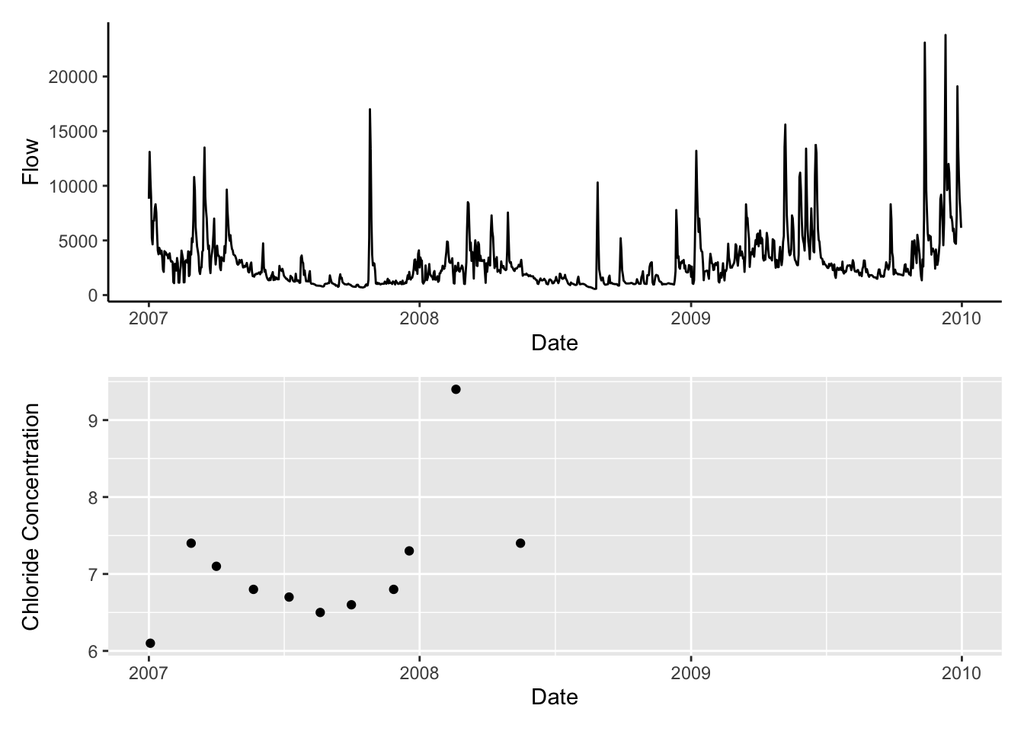

```r
wrap_plots (Flow/Chloride)
```

## Problem 5

Create a scatter plot of Specific Conductivity (y) and Chloride (x). Challenge: what could you do to get rid of the warning this plot generates about NAs.

```
## Warning: Removed 1089 rows containing missing values (geom_point).
```

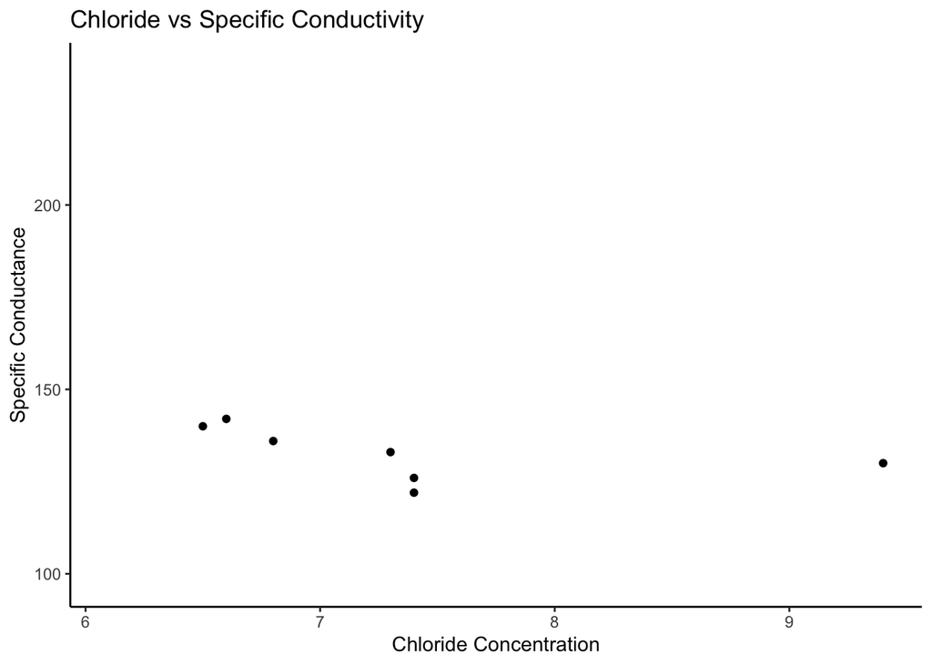

```r
ggplot(Rad_joined, aes (result_va, SpecCond)) +
  geom_point() +
  ggtitle("Chloride vs Specific Conductivity") +
  xlab("Chloride Concentration") +
  ylab("Specific Conductance") +
  theme_classic()
```

```r
# I could have done an inner_join instead of a left_join to remove NAs
```

## Problem 6

Read in the GG chem subset data and plot Mg_E1 (x) vs Ca_E1 (y) as points.

```r
GG <- read_csv("GG_chem_subest.csv")
```

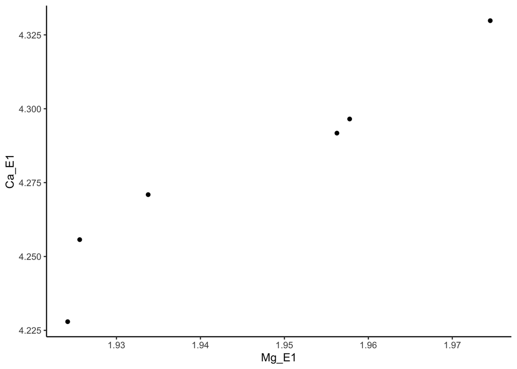

```r
GG %>% ggplot(aes(Mg_E1, Ca_E1)) +
  geom_point() +
  theme_classic()
```

## Problem 7

We want to look at concentrations of each element in the #6 dataset along the stream (Distance), which is difficult in the current format. Pivot the data into a long format, the data from Ca, Mg, and Na _E1 columns should be pivoted. Make line plots of each element where y is the concentration and x is distance. Use facet_wrap() to create a separate plot for each element and use the “scales” argument of facet_wrap to allow each plot to have different y limits.

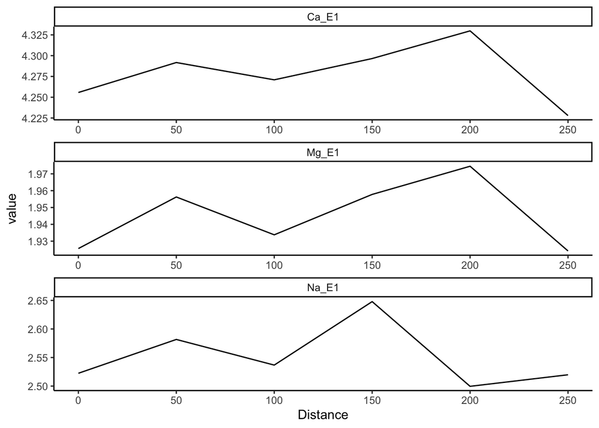

```r
GG_chem <- pivot_longer(GG, cols = c(Mg_E1, Ca_E1, Na_E1))

GG_chem %>%
  ggplot(aes(Distance, value)) +
  geom_line() +
  facet_wrap(facets = "name", nrow = 3, scales = "free") +
  theme_classic()
```

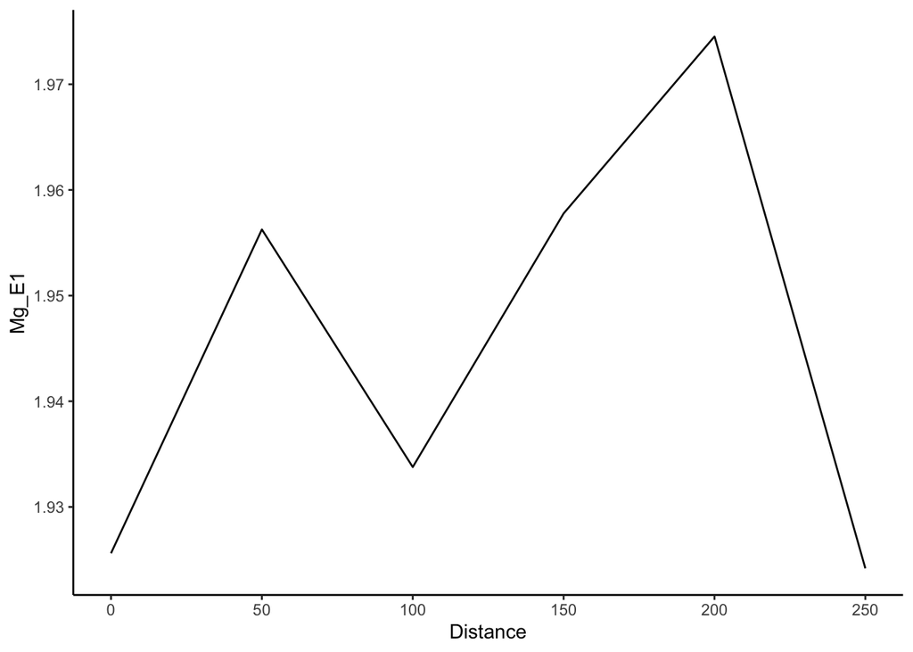

```r
#-or-

Mg <- GG %>%
    ggplot(aes(Distance, Mg_E1)) +
  geom_line() +
  theme_classic()

  Ca <- GG %>%
    ggplot(aes(Distance, Ca_E1)) +
  geom_line() +
  theme_classic()

  Na <- GG %>%
    ggplot(aes(Distance, Na_E1)) +
  geom_line() +
  theme_classic()

Mg
```

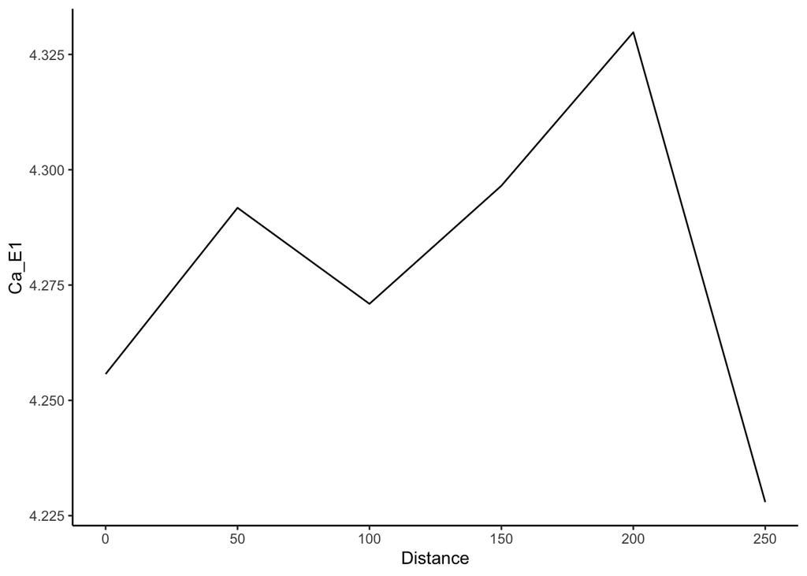

```r
Ca
```

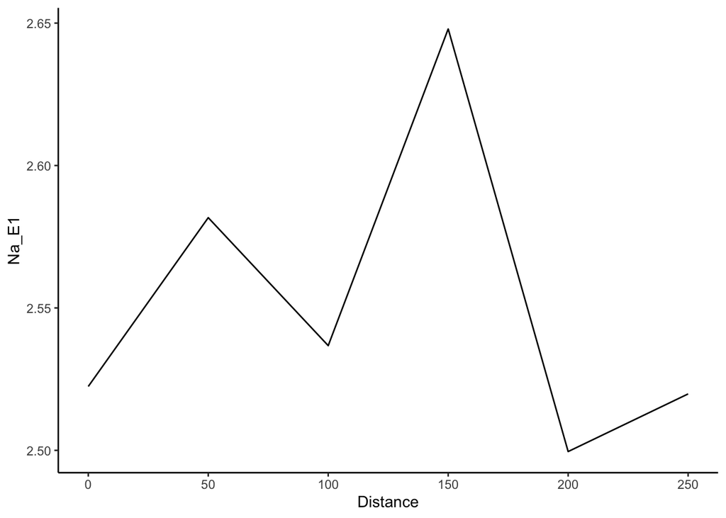

```r
Na
```

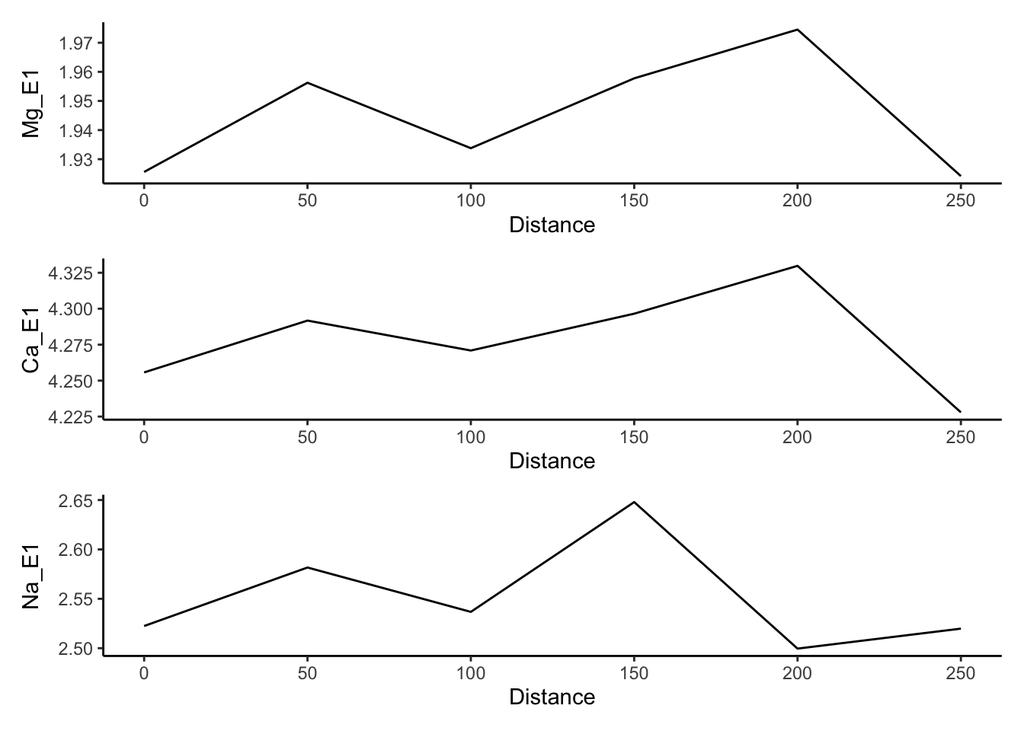

```r
wrap_plots(Mg,Ca, Na, nrow = 3)
```